# Risk Factor Analysis

## Outcome Variable

**Outcome Variable:** ever_stunted

## Predictor Variables

**Intervention Variable:** mwtkg

**Adjustment Set:**

- arm
- W_mage
- meducyrs
- feducyrs
- W_nchldlt5
- brthmon
- W_parity
- delta_W_mage
- delta_meducyrs
- delta_feducyrs
- delta_W_nchldlt5
- delta_brthmon
- delta_W_parity

## Stratifying Variables

The analysis was stratified on these variable(s):

- agecat
- studyid
- country

## Data Summary

| agecat | studyid | country | mwtkg | ever_stunted | n_cell | n |
| --- | --- | --- | --- | --- | --- | --- |
| 0-24 months | iLiNS-Zinc | BURKINA FASO | >=58 kg | 0 | 705 | 3216 |
| 0-24 months | iLiNS-Zinc | BURKINA FASO | >=58 kg | 1 | 232 | 3216 |
| 0-24 months | iLiNS-Zinc | BURKINA FASO | <52 kg | 0 | 658 | 3216 |
| 0-24 months | iLiNS-Zinc | BURKINA FASO | <52 kg | 1 | 543 | 3216 |
| 0-24 months | iLiNS-Zinc | BURKINA FASO | [52-58) kg | 0 | 706 | 3216 |
| 0-24 months | iLiNS-Zinc | BURKINA FASO | [52-58) kg | 1 | 372 | 3216 |
| 0-24 months | JiVitA-3 | BANGLADESH | >=58 kg | 0 | 405 | 27196 |
| 0-24 months | JiVitA-3 | BANGLADESH | >=58 kg | 1 | 264 | 27196 |
| 0-24 months | JiVitA-3 | BANGLADESH | <52 kg | 0 | 12291 | 27196 |
| 0-24 months | JiVitA-3 | BANGLADESH | <52 kg | 1 | 12462 | 27196 |
| 0-24 months | JiVitA-3 | BANGLADESH | [52-58) kg | 0 | 1028 | 27196 |
| 0-24 months | JiVitA-3 | BANGLADESH | [52-58) kg | 1 | 746 | 27196 |
| 0-24 months | LCNI-5 | MALAWI | >=58 kg | 0 | 55 | 838 |
| 0-24 months | LCNI-5 | MALAWI | >=58 kg | 1 | 59 | 838 |
| 0-24 months | LCNI-5 | MALAWI | <52 kg | 0 | 145 | 838 |
| 0-24 months | LCNI-5 | MALAWI | <52 kg | 1 | 359 | 838 |
| 0-24 months | LCNI-5 | MALAWI | [52-58) kg | 0 | 105 | 838 |
| 0-24 months | LCNI-5 | MALAWI | [52-58) kg | 1 | 115 | 838 |
| 0-24 months | MAL-ED | BANGLADESH | >=58 kg | 0 | 28 | 254 |
| 0-24 months | MAL-ED | BANGLADESH | >=58 kg | 1 | 20 | 254 |
| 0-24 months | MAL-ED | BANGLADESH | <52 kg | 0 | 49 | 254 |
| 0-24 months | MAL-ED | BANGLADESH | <52 kg | 1 | 113 | 254 |
| 0-24 months | MAL-ED | BANGLADESH | [52-58) kg | 0 | 21 | 254 |
| 0-24 months | MAL-ED | BANGLADESH | [52-58) kg | 1 | 23 | 254 |
| 0-24 months | MAL-ED | BRAZIL | >=58 kg | 0 | 106 | 221 |
| 0-24 months | MAL-ED | BRAZIL | >=58 kg | 1 | 37 | 221 |
| 0-24 months | MAL-ED | BRAZIL | <52 kg | 0 | 30 | 221 |
| 0-24 months | MAL-ED | BRAZIL | <52 kg | 1 | 12 | 221 |
| 0-24 months | MAL-ED | BRAZIL | [52-58) kg | 0 | 28 | 221 |
| 0-24 months | MAL-ED | BRAZIL | [52-58) kg | 1 | 8 | 221 |

[output cut: 270 more lines]

The following strata were considered:

- agecat: 0-24 months, studyid: iLiNS-Zinc, country: BURKINA FASO
- agecat: 0-24 months, studyid: JiVitA-3, country: BANGLADESH
- agecat: 0-24 months, studyid: LCNI-5, country: MALAWI
- agecat: 0-24 months, studyid: MAL-ED, country: BANGLADESH
- agecat: 0-24 months, studyid: MAL-ED, country: BRAZIL
- agecat: 0-24 months, studyid: MAL-ED, country: INDIA
- agecat: 0-24 months, studyid: MAL-ED, country: NEPAL
- agecat: 0-24 months, studyid: MAL-ED, country: PERU
- agecat: 0-24 months, studyid: MAL-ED, country: SOUTH AFRICA
- agecat: 0-24 months, studyid: MAL-ED, country: TANZANIA, UNITED REPUBLIC OF
- agecat: 0-24 months, studyid: NIH-Birth, country: BANGLADESH
- agecat: 0-24 months, studyid: NIH-Crypto, country: BANGLADESH
- agecat: 0-24 months, studyid: PROBIT, country: BELARUS
- agecat: 0-24 months, studyid: PROVIDE, country: BANGLADESH
- agecat: 0-24 months, studyid: SAS-CompFeed, country: INDIA
- agecat: 0-24 months, studyid: TanzaniaChild2, country: TANZANIA, UNITED REPUBLIC OF
- agecat: 0-24 months, studyid: ZVITAMBO, country: ZIMBABWE
- agecat: 0-6 months, studyid: JiVitA-3, country: BANGLADESH
- agecat: 0-6 months, studyid: LCNI-5, country: MALAWI
- agecat: 0-6 months, studyid: MAL-ED, country: BANGLADESH
- agecat: 0-6 months, studyid: MAL-ED, country: BRAZIL
- agecat: 0-6 months, studyid: MAL-ED, country: INDIA
- agecat: 0-6 months, studyid: MAL-ED, country: NEPAL
- agecat: 0-6 months, studyid: MAL-ED, country: PERU
- agecat: 0-6 months, studyid: MAL-ED, country: SOUTH AFRICA
- agecat: 0-6 months, studyid: MAL-ED, country: TANZANIA, UNITED REPUBLIC OF
- agecat: 0-6 months, studyid: NIH-Birth, country: BANGLADESH
- agecat: 0-6 months, studyid: NIH-Crypto, country: BANGLADESH
- agecat: 0-6 months, studyid: PROBIT, country: BELARUS
- agecat: 0-6 months, studyid: PROVIDE, country: BANGLADESH
- agecat: 0-6 months, studyid: SAS-CompFeed, country: INDIA
- agecat: 0-6 months, studyid: TanzaniaChild2, country: TANZANIA, UNITED REPUBLIC OF
- agecat: 0-6 months, studyid: ZVITAMBO, country: ZIMBABWE
- agecat: 6-24 months, studyid: iLiNS-Zinc, country: BURKINA FASO
- agecat: 6-24 months, studyid: JiVitA-3, country: BANGLADESH
- agecat: 6-24 months, studyid: LCNI-5, country: MALAWI
- agecat: 6-24 months, studyid: MAL-ED, country: BANGLADESH
- agecat: 6-24 months, studyid: MAL-ED, country: BRAZIL
- agecat: 6-24 months, studyid: MAL-ED, country: INDIA
- agecat: 6-24 months, studyid: MAL-ED, country: NEPAL
- agecat: 6-24 months, studyid: MAL-ED, country: PERU
- agecat: 6-24 months, studyid: MAL-ED, country: SOUTH AFRICA
- agecat: 6-24 months, studyid: MAL-ED, country: TANZANIA, UNITED REPUBLIC OF
- agecat: 6-24 months, studyid: NIH-Birth, country: BANGLADESH
- agecat: 6-24 months, studyid: NIH-Crypto, country: BANGLADESH
- agecat: 6-24 months, studyid: PROBIT, country: BELARUS
- agecat: 6-24 months, studyid: PROVIDE, country: BANGLADESH
- agecat: 6-24 months, studyid: SAS-CompFeed, country: INDIA
- agecat: 6-24 months, studyid: TanzaniaChild2, country: TANZANIA, UNITED REPUBLIC OF
- agecat: 6-24 months, studyid: ZVITAMBO, country: ZIMBABWE

### Dropped Strata

Some strata were dropped due to rare outcomes:

- agecat: 6-24 months, studyid: MAL-ED, country: BRAZIL

## Methods Detail

We're interested in the causal parameters $E[Y_a]$ for all values of $a \in \mathcal{A}$. These parameters represent the mean outcome if, possibly contrary to fact, we intervened to set all units to have $A=a$. Under the randomization and positivity assumptions, these are identified by the statistical parameters $\psi_a=E_W[E_{Y|A,W}(Y|A=a,W)]$. In addition, we're interested in the mean of $Y$, $E[Y]$ under no intervention (the observed mean). We will estimate these parameters by using SuperLearner to fit the relevant likelihood factors -- $E_{Y|A,W}(Y|A=a,W)$ and $p(A=a|W)$, and then updating our likelihood fit using a joint TMLE.

For unadjusted analyses ($W=\{\}$), initial likelihoods were estimated using Lrnr_glm to estimate the simple $E(Y|A)$ and Lrnr_mean to estimate $p(A)$. For adjusted analyses, a small library containing Lrnr_glmnet, Lrnr_xgboost, and Lrnr_mean was used.

Having estimated these parameters, we will then use the delta method to estimate relative risks and attributable risks relative to a prespecified baseline level of $A$.

# Results Detail

## Results Plots

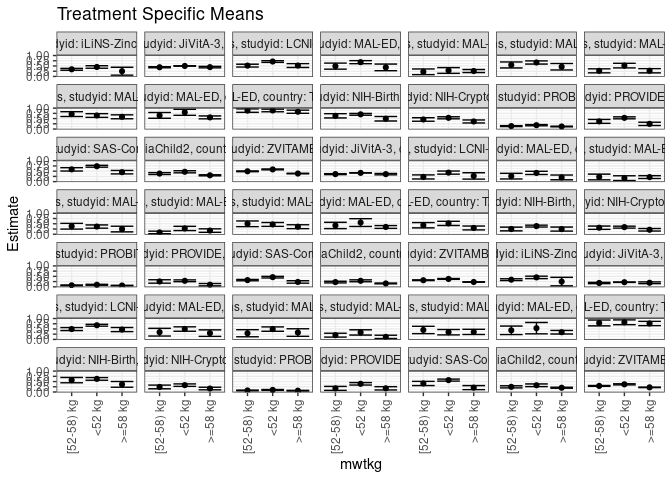

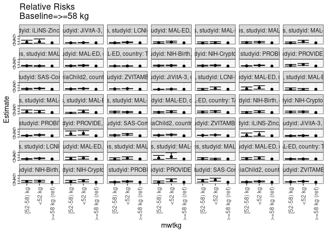

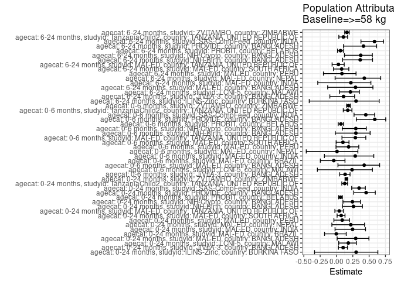

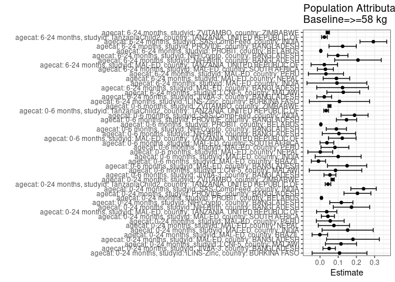

## Results Table

### Parameter: TSM

| agecat | studyid | country | intervention_level | baseline_level | estimate | ci_lower | ci_upper |
| --- | --- | --- | --- | --- | --- | --- | --- |
| 0-24 months | iLiNS-Zinc | BURKINA FASO | >=58 kg | NA | 0.2493530 | 0.0603175 | 0.4383885 |
| 0-24 months | iLiNS-Zinc | BURKINA FASO | <52 kg | NA | 0.4516361 | 0.3917896 | 0.5114826 |
| 0-24 months | iLiNS-Zinc | BURKINA FASO | [52-58) kg | NA | 0.3420699 | 0.2987834 | 0.3853564 |
| 0-24 months | JiVitA-3 | BANGLADESH | >=58 kg | NA | 0.4450505 | 0.4103869 | 0.4797140 |
| 0-24 months | JiVitA-3 | BANGLADESH | <52 kg | NA | 0.5012424 | 0.4931678 | 0.5093170 |
| 0-24 months | JiVitA-3 | BANGLADESH | [52-58) kg | NA | 0.4393183 | 0.4148068 | 0.4638299 |
| 0-24 months | LCNI-5 | MALAWI | >=58 kg | NA | 0.5209312 | 0.4285223 | 0.6133400 |
| 0-24 months | LCNI-5 | MALAWI | <52 kg | NA | 0.7135603 | 0.6740034 | 0.7531171 |
| 0-24 months | LCNI-5 | MALAWI | [52-58) kg | NA | 0.5179666 | 0.4505161 | 0.5854171 |
| 0-24 months | MAL-ED | BANGLADESH | >=58 kg | NA | 0.4332183 | 0.2744105 | 0.5920260 |
| 0-24 months | MAL-ED | BANGLADESH | <52 kg | NA | 0.6827095 | 0.6095394 | 0.7558795 |
| 0-24 months | MAL-ED | BANGLADESH | [52-58) kg | NA | 0.4926446 | 0.3467692 | 0.6385200 |
| 0-24 months | MAL-ED | BRAZIL | >=58 kg | NA | 0.2587413 | 0.1867992 | 0.3306833 |
| 0-24 months | MAL-ED | BRAZIL | <52 kg | NA | 0.2857143 | 0.1487806 | 0.4226479 |
| 0-24 months | MAL-ED | BRAZIL | [52-58) kg | NA | 0.2222222 | 0.0861081 | 0.3583363 |
| 0-24 months | MAL-ED | INDIA | >=58 kg | NA | 0.4638460 | 0.3095006 | 0.6181914 |
| 0-24 months | MAL-ED | INDIA | <52 kg | NA | 0.6671050 | 0.5916666 | 0.7425433 |
| 0-24 months | MAL-ED | INDIA | [52-58) kg | NA | 0.5498849 | 0.4067449 | 0.6930249 |
| 0-24 months | MAL-ED | NEPAL | >=58 kg | NA | 0.2724614 | 0.1706699 | 0.3742528 |
| 0-24 months | MAL-ED | NEPAL | <52 kg | NA | 0.5179918 | 0.4080001 | 0.6279834 |
| 0-24 months | MAL-ED | NEPAL | [52-58) kg | NA | 0.2684135 | 0.1721510 | 0.3646760 |
| 0-24 months | MAL-ED | PERU | >=58 kg | NA | 0.5850470 | 0.4900618 | 0.6800322 |
| 0-24 months | MAL-ED | PERU | <52 kg | NA | 0.6465471 | 0.5581775 | 0.7349167 |
| 0-24 months | MAL-ED | PERU | [52-58) kg | NA | 0.7149918 | 0.6001673 | 0.8298164 |
| 0-24 months | MAL-ED | SOUTH AFRICA | >=58 kg | NA | 0.5567010 | 0.4866665 | 0.6267356 |
| 0-24 months | MAL-ED | SOUTH AFRICA | <52 kg | NA | 0.8000000 | 0.6565987 | 0.9434013 |
| 0-24 months | MAL-ED | SOUTH AFRICA | [52-58) kg | NA | 0.6521739 | 0.5142823 | 0.7900655 |
| 0-24 months | MAL-ED | TANZANIA, UNITED REPUBLIC OF | >=58 kg | NA | 0.8265306 | 0.7514158 | 0.9016455 |
| 0-24 months | MAL-ED | TANZANIA, UNITED REPUBLIC OF | <52 kg | NA | 0.8888889 | 0.8268616 | 0.9509162 |
| 0-24 months | MAL-ED | TANZANIA, UNITED REPUBLIC OF | [52-58) kg | NA | 0.8813559 | 0.7986816 | 0.9640303 |

[output cut: 117 more lines]

### Parameter: E(Y)

| agecat | studyid | country | intervention_level | baseline_level | estimate | ci_lower | ci_upper |
| --- | --- | --- | --- | --- | --- | --- | --- |
| 0-24 months | iLiNS-Zinc | BURKINA FASO | NA | NA | 0.3566542 | 0.3069876 | 0.4063208 |
| 0-24 months | JiVitA-3 | BANGLADESH | NA | NA | 0.4953670 | 0.4875503 | 0.5031837 |
| 0-24 months | LCNI-5 | MALAWI | NA | NA | 0.6360382 | 0.6034429 | 0.6686335 |
| 0-24 months | MAL-ED | BANGLADESH | NA | NA | 0.6141732 | 0.5541901 | 0.6741564 |
| 0-24 months | MAL-ED | BRAZIL | NA | NA | 0.2579186 | 0.2001084 | 0.3157287 |
| 0-24 months | MAL-ED | INDIA | NA | NA | 0.6157025 | 0.5542897 | 0.6771153 |
| 0-24 months | MAL-ED | NEPAL | NA | NA | 0.3487395 | 0.2880656 | 0.4094134 |
| 0-24 months | MAL-ED | PERU | NA | NA | 0.6413793 | 0.5860858 | 0.6966728 |
| 0-24 months | MAL-ED | SOUTH AFRICA | NA | NA | 0.6000000 | 0.5414566 | 0.6585434 |
| 0-24 months | MAL-ED | TANZANIA, UNITED REPUBLIC OF | NA | NA | 0.8632812 | 0.8211147 | 0.9054478 |
| 0-24 months | NIH-Birth | BANGLADESH | NA | NA | 0.6645469 | 0.6276196 | 0.7014742 |
| 0-24 months | NIH-Crypto | BANGLADESH | NA | NA | 0.4794702 | 0.4438115 | 0.5151289 |
| 0-24 months | PROBIT | BELARUS | NA | NA | 0.1289573 | 0.1128390 | 0.1450756 |
| 0-24 months | PROVIDE | BANGLADESH | NA | NA | 0.4529148 | 0.4151667 | 0.4906629 |
| 0-24 months | SAS-CompFeed | INDIA | NA | NA | 0.6910891 | 0.6503148 | 0.7318634 |
| 0-24 months | TanzaniaChild2 | TANZANIA, UNITED REPUBLIC OF | NA | NA | 0.3465136 | 0.3272783 | 0.3657490 |
| 0-24 months | ZVITAMBO | ZIMBABWE | NA | NA | 0.4563549 | 0.4471315 | 0.4655783 |
| 0-6 months | JiVitA-3 | BANGLADESH | NA | NA | 0.4129746 | 0.4055418 | 0.4204074 |
| 0-6 months | LCNI-5 | MALAWI | NA | NA | 0.3579336 | 0.3007518 | 0.4151153 |
| 0-6 months | MAL-ED | BANGLADESH | NA | NA | 0.3503937 | 0.2916054 | 0.4091820 |
| 0-6 months | MAL-ED | BRAZIL | NA | NA | 0.2081448 | 0.1544982 | 0.2617914 |
| 0-6 months | MAL-ED | INDIA | NA | NA | 0.3471074 | 0.2870050 | 0.4072099 |
| 0-6 months | MAL-ED | NEPAL | NA | NA | 0.1764706 | 0.1279362 | 0.2250050 |
| 0-6 months | MAL-ED | PERU | NA | NA | 0.4413793 | 0.3841309 | 0.4986278 |
| 0-6 months | MAL-ED | SOUTH AFRICA | NA | NA | 0.3851852 | 0.3270313 | 0.4433391 |
| 0-6 months | MAL-ED | TANZANIA, UNITED REPUBLIC OF | NA | NA | 0.4218750 | 0.3612599 | 0.4824901 |
| 0-6 months | NIH-Birth | BANGLADESH | NA | NA | 0.3497615 | 0.3124631 | 0.3870600 |
| 0-6 months | NIH-Crypto | BANGLADESH | NA | NA | 0.3033113 | 0.2704998 | 0.3361228 |
| 0-6 months | PROBIT | BELARUS | NA | NA | 0.0659309 | 0.0552270 | 0.0766347 |
| 0-6 months | PROVIDE | BANGLADESH | NA | NA | 0.2481315 | 0.2153770 | 0.2808861 |
| 0-6 months | SAS-CompFeed | INDIA | NA | NA | 0.4226190 | 0.3935114 | 0.4517267 |
| 0-6 months | TanzaniaChild2 | TANZANIA, UNITED REPUBLIC OF | NA | NA | 0.1943027 | 0.1783091 | 0.2102964 |
| 0-6 months | ZVITAMBO | ZIMBABWE | NA | NA | 0.2824844 | 0.2741425 | 0.2908263 |
| 6-24 months | iLiNS-Zinc | BURKINA FASO | NA | NA | 0.3566542 | 0.3069876 | 0.4063208 |
| 6-24 months | JiVitA-3 | BANGLADESH | NA | NA | 0.2162884 | 0.2069101 | 0.2256667 |
| 6-24 months | LCNI-5 | MALAWI | NA | NA | 0.5989011 | 0.5632737 | 0.6345285 |
| 6-24 months | MAL-ED | BANGLADESH | NA | NA | 0.4240506 | 0.3467471 | 0.5013542 |
| 6-24 months | MAL-ED | INDIA | NA | NA | 0.4220779 | 0.3438191 | 0.5003367 |
| 6-24 months | MAL-ED | NEPAL | NA | NA | 0.2113402 | 0.1537425 | 0.2689379 |
| 6-24 months | MAL-ED | PERU | NA | NA | 0.3918919 | 0.3129763 | 0.4708075 |
| 6-24 months | MAL-ED | SOUTH AFRICA | NA | NA | 0.3741935 | 0.2977649 | 0.4506221 |
| 6-24 months | MAL-ED | TANZANIA, UNITED REPUBLIC OF | NA | NA | 0.7847222 | 0.7173567 | 0.8520877 |
| 6-24 months | NIH-Birth | BANGLADESH | NA | NA | 0.5739130 | 0.5216565 | 0.6261696 |
| 6-24 months | NIH-Crypto | BANGLADESH | NA | NA | 0.2628458 | 0.2244546 | 0.3012371 |
| 6-24 months | PROBIT | BELARUS | NA | NA | 0.0675171 | 0.0551317 | 0.0799025 |
| 6-24 months | PROVIDE | BANGLADESH | NA | NA | 0.3004386 | 0.2583143 | 0.3425629 |
| 6-24 months | SAS-CompFeed | INDIA | NA | NA | 0.5030826 | 0.4587775 | 0.5473878 |
| 6-24 months | TanzaniaChild2 | TANZANIA, UNITED REPUBLIC OF | NA | NA | 0.2277354 | 0.2069978 | 0.2484730 |
| 6-24 months | ZVITAMBO | ZIMBABWE | NA | NA | 0.2645703 | 0.2545045 | 0.2746362 |

### Parameter: RR

| agecat | studyid | country | intervention_level | baseline_level | estimate | ci_lower | ci_upper |
| --- | --- | --- | --- | --- | --- | --- | --- |
| 0-24 months | iLiNS-Zinc | BURKINA FASO | >=58 kg | >=58 kg | 1.0000000 | 1.0000000 | 1.000000 |
| 0-24 months | iLiNS-Zinc | BURKINA FASO | <52 kg | >=58 kg | 1.8112320 | 0.8364084 | 3.922200 |
| 0-24 months | iLiNS-Zinc | BURKINA FASO | [52-58) kg | >=58 kg | 1.3718300 | 0.6327212 | 2.974324 |
| 0-24 months | JiVitA-3 | BANGLADESH | >=58 kg | >=58 kg | 1.0000000 | 1.0000000 | 1.000000 |
| 0-24 months | JiVitA-3 | BANGLADESH | <52 kg | >=58 kg | 1.1262596 | 1.0410056 | 1.218496 |
| 0-24 months | JiVitA-3 | BANGLADESH | [52-58) kg | >=58 kg | 0.9871203 | 0.8989258 | 1.083968 |
| 0-24 months | LCNI-5 | MALAWI | >=58 kg | >=58 kg | 1.0000000 | 1.0000000 | 1.000000 |
| 0-24 months | LCNI-5 | MALAWI | <52 kg | >=58 kg | 1.3697784 | 1.1374710 | 1.649530 |
| 0-24 months | LCNI-5 | MALAWI | [52-58) kg | >=58 kg | 0.9943090 | 0.7977936 | 1.239231 |
| 0-24 months | MAL-ED | BANGLADESH | >=58 kg | >=58 kg | 1.0000000 | 1.0000000 | 1.000000 |
| 0-24 months | MAL-ED | BANGLADESH | <52 kg | >=58 kg | 1.5759019 | 1.0740610 | 2.312222 |
| 0-24 months | MAL-ED | BANGLADESH | [52-58) kg | >=58 kg | 1.1371741 | 0.7092165 | 1.823371 |
| 0-24 months | MAL-ED | BRAZIL | >=58 kg | >=58 kg | 1.0000000 | 1.0000000 | 1.000000 |
| 0-24 months | MAL-ED | BRAZIL | <52 kg | >=58 kg | 1.1042471 | 0.6344996 | 1.921769 |
| 0-24 months | MAL-ED | BRAZIL | [52-58) kg | >=58 kg | 0.8588589 | 0.4383144 | 1.682898 |
| 0-24 months | MAL-ED | INDIA | >=58 kg | >=58 kg | 1.0000000 | 1.0000000 | 1.000000 |
| 0-24 months | MAL-ED | INDIA | <52 kg | >=58 kg | 1.4382037 | 1.0107875 | 2.046355 |
| 0-24 months | MAL-ED | INDIA | [52-58) kg | >=58 kg | 1.1854903 | 0.7764541 | 1.810007 |
| 0-24 months | MAL-ED | NEPAL | >=58 kg | >=58 kg | 1.0000000 | 1.0000000 | 1.000000 |
| 0-24 months | MAL-ED | NEPAL | <52 kg | >=58 kg | 1.9011568 | 1.2348711 | 2.926943 |
| 0-24 months | MAL-ED | NEPAL | [52-58) kg | >=58 kg | 0.9851435 | 0.5853532 | 1.657986 |
| 0-24 months | MAL-ED | PERU | >=58 kg | >=58 kg | 1.0000000 | 1.0000000 | 1.000000 |
| 0-24 months | MAL-ED | PERU | <52 kg | >=58 kg | 1.1051199 | 0.8934626 | 1.366918 |
| 0-24 months | MAL-ED | PERU | [52-58) kg | >=58 kg | 1.2221101 | 0.9722313 | 1.536212 |
| 0-24 months | MAL-ED | SOUTH AFRICA | >=58 kg | >=58 kg | 1.0000000 | 1.0000000 | 1.000000 |
| 0-24 months | MAL-ED | SOUTH AFRICA | <52 kg | >=58 kg | 1.4370370 | 1.1544123 | 1.788854 |
| 0-24 months | MAL-ED | SOUTH AFRICA | [52-58) kg | >=58 kg | 1.1714976 | 0.9159929 | 1.498272 |
| 0-24 months | MAL-ED | TANZANIA, UNITED REPUBLIC OF | >=58 kg | >=58 kg | 1.0000000 | 1.0000000 | 1.000000 |
| 0-24 months | MAL-ED | TANZANIA, UNITED REPUBLIC OF | <52 kg | >=58 kg | 1.0754458 | 0.9590191 | 1.206007 |
| 0-24 months | MAL-ED | TANZANIA, UNITED REPUBLIC OF | [52-58) kg | >=58 kg | 1.0663319 | 0.9357728 | 1.215107 |

[output cut: 117 more lines]

### Parameter: PAR

| agecat | studyid | country | intervention_level | baseline_level | estimate | ci_lower | ci_upper |
| --- | --- | --- | --- | --- | --- | --- | --- |
| 0-24 months | iLiNS-Zinc | BURKINA FASO | >=58 kg | NA | 0.1073013 | -0.0433367 | 0.2579392 |
| 0-24 months | JiVitA-3 | BANGLADESH | >=58 kg | NA | 0.0503165 | 0.0161547 | 0.0844783 |
| 0-24 months | LCNI-5 | MALAWI | >=58 kg | NA | 0.1151070 | 0.0295957 | 0.2006184 |
| 0-24 months | MAL-ED | BANGLADESH | >=58 kg | NA | 0.1809550 | 0.0358968 | 0.3260131 |
| 0-24 months | MAL-ED | BRAZIL | >=58 kg | NA | -0.0008227 | -0.0434813 | 0.0418359 |
| 0-24 months | MAL-ED | INDIA | >=58 kg | NA | 0.1518565 | 0.0113812 | 0.2923318 |
| 0-24 months | MAL-ED | NEPAL | >=58 kg | NA | 0.0762781 | -0.0094581 | 0.1620143 |
| 0-24 months | MAL-ED | PERU | >=58 kg | NA | 0.0563323 | -0.0200261 | 0.1326908 |
| 0-24 months | MAL-ED | SOUTH AFRICA | >=58 kg | NA | 0.0432990 | 0.0074698 | 0.0791281 |
| 0-24 months | MAL-ED | TANZANIA, UNITED REPUBLIC OF | >=58 kg | NA | 0.0367506 | -0.0189308 | 0.0924320 |
| 0-24 months | NIH-Birth | BANGLADESH | >=58 kg | NA | 0.1729046 | 0.0729371 | 0.2728720 |
| 0-24 months | NIH-Crypto | BANGLADESH | >=58 kg | NA | 0.1172232 | 0.0536121 | 0.1808343 |
| 0-24 months | PROBIT | BELARUS | >=58 kg | NA | 0.0080318 | 0.0045919 | 0.0114716 |
| 0-24 months | PROVIDE | BANGLADESH | >=58 kg | NA | 0.2055904 | 0.1316372 | 0.2795436 |
| 0-24 months | SAS-CompFeed | INDIA | >=58 kg | NA | 0.2391644 | 0.1693339 | 0.3089950 |
| 0-24 months | TanzaniaChild2 | TANZANIA, UNITED REPUBLIC OF | >=58 kg | NA | 0.0438973 | 0.0285846 | 0.0592101 |
| 0-24 months | ZVITAMBO | ZIMBABWE | >=58 kg | NA | 0.0692096 | 0.0602106 | 0.0782086 |
| 0-6 months | JiVitA-3 | BANGLADESH | >=58 kg | NA | 0.0545337 | 0.0217949 | 0.0872725 |
| 0-6 months | LCNI-5 | MALAWI | >=58 kg | NA | 0.0852063 | -0.0590172 | 0.2294298 |
| 0-6 months | MAL-ED | BANGLADESH | >=58 kg | NA | 0.1487237 | 0.0409271 | 0.2565202 |
| 0-6 months | MAL-ED | BRAZIL | >=58 kg | NA | -0.0086384 | -0.0477583 | 0.0304815 |
| 0-6 months | MAL-ED | INDIA | >=58 kg | NA | 0.0997476 | -0.0263695 | 0.2258647 |
| 0-6 months | MAL-ED | NEPAL | >=58 kg | NA | 0.0014706 | -0.0666265 | 0.0695677 |
| 0-6 months | MAL-ED | PERU | >=58 kg | NA | 0.0819991 | 0.0054247 | 0.1585736 |
| 0-6 months | MAL-ED | SOUTH AFRICA | >=58 kg | NA | 0.0379383 | 0.0000529 | 0.0758236 |
| 0-6 months | MAL-ED | TANZANIA, UNITED REPUBLIC OF | >=58 kg | NA | 0.1221624 | 0.0463127 | 0.1980121 |
| 0-6 months | NIH-Birth | BANGLADESH | >=58 kg | NA | 0.1039276 | 0.0124000 | 0.1954552 |
| 0-6 months | NIH-Crypto | BANGLADESH | >=58 kg | NA | 0.0897734 | 0.0342768 | 0.1452700 |
| 0-6 months | PROBIT | BELARUS | >=58 kg | NA | 0.0045103 | 0.0017686 | 0.0072521 |
| 0-6 months | PROVIDE | BANGLADESH | >=58 kg | NA | 0.1455931 | 0.0899806 | 0.2012056 |
| 0-6 months | SAS-CompFeed | INDIA | >=58 kg | NA | 0.1897839 | 0.1155370 | 0.2640307 |
| 0-6 months | TanzaniaChild2 | TANZANIA, UNITED REPUBLIC OF | >=58 kg | NA | 0.0335964 | 0.0205177 | 0.0466751 |
| 0-6 months | ZVITAMBO | ZIMBABWE | >=58 kg | NA | 0.0519005 | 0.0437269 | 0.0600742 |
| 6-24 months | iLiNS-Zinc | BURKINA FASO | >=58 kg | NA | 0.1068333 | -0.0583896 | 0.2720563 |
| 6-24 months | JiVitA-3 | BANGLADESH | >=58 kg | NA | 0.0233178 | -0.0174920 | 0.0641275 |
| 6-24 months | LCNI-5 | MALAWI | >=58 kg | NA | 0.1278485 | 0.0376138 | 0.2180831 |
| 6-24 months | MAL-ED | BANGLADESH | >=58 kg | NA | 0.1237499 | -0.0180040 | 0.2655037 |
| 6-24 months | MAL-ED | INDIA | >=58 kg | NA | 0.0928899 | -0.0714234 | 0.2572032 |
| 6-24 months | MAL-ED | NEPAL | >=58 kg | NA | 0.0901281 | 0.0172641 | 0.1629921 |
| 6-24 months | MAL-ED | PERU | >=58 kg | NA | 0.0326091 | -0.0639600 | 0.1291781 |
| 6-24 months | MAL-ED | SOUTH AFRICA | >=58 kg | NA | 0.0296557 | -0.0140735 | 0.0733850 |
| 6-24 months | MAL-ED | TANZANIA, UNITED REPUBLIC OF | >=58 kg | NA | 0.0235282 | -0.0490455 | 0.0961019 |
| 6-24 months | NIH-Birth | BANGLADESH | >=58 kg | NA | 0.2084438 | 0.0806767 | 0.3362108 |
| 6-24 months | NIH-Crypto | BANGLADESH | >=58 kg | NA | 0.0975547 | 0.0417528 | 0.1533566 |
| 6-24 months | PROBIT | BELARUS | >=58 kg | NA | 0.0041536 | 0.0014184 | 0.0068889 |
| 6-24 months | PROVIDE | BANGLADESH | >=58 kg | NA | 0.1242428 | 0.0491142 | 0.1993713 |
| 6-24 months | SAS-CompFeed | INDIA | >=58 kg | NA | 0.2929306 | 0.2195259 | 0.3663354 |
| 6-24 months | TanzaniaChild2 | TANZANIA, UNITED REPUBLIC OF | >=58 kg | NA | 0.0240970 | 0.0087066 | 0.0394874 |
| 6-24 months | ZVITAMBO | ZIMBABWE | >=58 kg | NA | 0.0426488 | 0.0334259 | 0.0518717 |

### Parameter: PAF

| agecat | studyid | country | intervention_level | baseline_level | estimate | ci_lower | ci_upper |
| --- | --- | --- | --- | --- | --- | --- | --- |
| 0-24 months | iLiNS-Zinc | BURKINA FASO | >=58 kg | NA | 0.3008551 | -0.3363746 | 0.6342316 |
| 0-24 months | JiVitA-3 | BANGLADESH | >=58 kg | NA | 0.1015742 | 0.0299618 | 0.1678998 |
| 0-24 months | LCNI-5 | MALAWI | >=58 kg | NA | 0.1809750 | 0.0341687 | 0.3054668 |
| 0-24 months | MAL-ED | BANGLADESH | >=58 kg | NA | 0.2946318 | 0.0103202 | 0.4972674 |
| 0-24 months | MAL-ED | BRAZIL | >=58 kg | NA | -0.0031898 | -0.1830006 | 0.1492905 |
| 0-24 months | MAL-ED | INDIA | >=58 kg | NA | 0.2466395 | -0.0222338 | 0.4447923 |
| 0-24 months | MAL-ED | NEPAL | >=58 kg | NA | 0.2187253 | -0.0708732 | 0.4300070 |
| 0-24 months | MAL-ED | PERU | >=58 kg | NA | 0.0878300 | -0.0397530 | 0.1997579 |
| 0-24 months | MAL-ED | SOUTH AFRICA | >=58 kg | NA | 0.0721649 | 0.0097011 | 0.1306889 |
| 0-24 months | MAL-ED | TANZANIA, UNITED REPUBLIC OF | >=58 kg | NA | 0.0425709 | -0.0245477 | 0.1052924 |
| 0-24 months | NIH-Birth | BANGLADESH | >=58 kg | NA | 0.2601842 | 0.0918907 | 0.3972890 |
| 0-24 months | NIH-Crypto | BANGLADESH | >=58 kg | NA | 0.2444848 | 0.0989255 | 0.3665306 |
| 0-24 months | PROBIT | BELARUS | >=58 kg | NA | 0.0622823 | 0.0331309 | 0.0905547 |
| 0-24 months | PROVIDE | BANGLADESH | >=58 kg | NA | 0.4539274 | 0.2643069 | 0.5946743 |
| 0-24 months | SAS-CompFeed | INDIA | >=58 kg | NA | 0.3460689 | 0.2329430 | 0.4425109 |
| 0-24 months | TanzaniaChild2 | TANZANIA, UNITED REPUBLIC OF | >=58 kg | NA | 0.1266829 | 0.0814008 | 0.1697328 |
| 0-24 months | ZVITAMBO | ZIMBABWE | >=58 kg | NA | 0.1516575 | 0.1316073 | 0.1712447 |
| 0-6 months | JiVitA-3 | BANGLADESH | >=58 kg | NA | 0.1320511 | 0.0491361 | 0.2077359 |
| 0-6 months | LCNI-5 | MALAWI | >=58 kg | NA | 0.2380506 | -0.2925147 | 0.5508238 |
| 0-6 months | MAL-ED | BANGLADESH | >=58 kg | NA | 0.4244473 | 0.0224189 | 0.6611423 |
| 0-6 months | MAL-ED | BRAZIL | >=58 kg | NA | -0.0415020 | -0.2473085 | 0.1303464 |
| 0-6 months | MAL-ED | INDIA | >=58 kg | NA | 0.2873681 | -0.1853719 | 0.5715739 |
| 0-6 months | MAL-ED | NEPAL | >=58 kg | NA | 0.0083333 | -0.4633876 | 0.3279957 |
| 0-6 months | MAL-ED | PERU | >=58 kg | NA | 0.1857792 | -0.0074219 | 0.3419287 |
| 0-6 months | MAL-ED | SOUTH AFRICA | >=58 kg | NA | 0.0984936 | -0.0055445 | 0.1917675 |
| 0-6 months | MAL-ED | TANZANIA, UNITED REPUBLIC OF | >=58 kg | NA | 0.2895702 | 0.0839648 | 0.4490271 |
| 0-6 months | NIH-Birth | BANGLADESH | >=58 kg | NA | 0.2971385 | -0.0196987 | 0.5155292 |
| 0-6 months | NIH-Crypto | BANGLADESH | >=58 kg | NA | 0.2959778 | 0.0884865 | 0.4562371 |
| 0-6 months | PROBIT | BELARUS | >=58 kg | NA | 0.0684099 | 0.0261016 | 0.1088803 |
| 0-6 months | PROVIDE | BANGLADESH | >=58 kg | NA | 0.5867578 | 0.3040626 | 0.7546200 |
| 0-6 months | SAS-CompFeed | INDIA | >=58 kg | NA | 0.4490660 | 0.2689735 | 0.5847917 |
| 0-6 months | TanzaniaChild2 | TANZANIA, UNITED REPUBLIC OF | >=58 kg | NA | 0.1729076 | 0.1038109 | 0.2366770 |
| 0-6 months | ZVITAMBO | ZIMBABWE | >=58 kg | NA | 0.1837289 | 0.1544755 | 0.2119702 |
| 6-24 months | iLiNS-Zinc | BURKINA FASO | >=58 kg | NA | 0.2995432 | -0.4175387 | 0.6538791 |
| 6-24 months | JiVitA-3 | BANGLADESH | >=58 kg | NA | 0.1078086 | -0.1019186 | 0.2776187 |
| 6-24 months | LCNI-5 | MALAWI | >=58 kg | NA | 0.2134717 | 0.0464208 | 0.3512582 |
| 6-24 months | MAL-ED | BANGLADESH | >=58 kg | NA | 0.2918280 | -0.1351619 | 0.5582062 |
| 6-24 months | MAL-ED | INDIA | >=58 kg | NA | 0.2200776 | -0.2868791 | 0.5273224 |
| 6-24 months | MAL-ED | NEPAL | >=58 kg | NA | 0.4264597 | -0.0212821 | 0.6779064 |
| 6-24 months | MAL-ED | PERU | >=58 kg | NA | 0.0832093 | -0.1998387 | 0.2994849 |
| 6-24 months | MAL-ED | SOUTH AFRICA | >=58 kg | NA | 0.0792524 | -0.0454791 | 0.1891027 |
| 6-24 months | MAL-ED | TANZANIA, UNITED REPUBLIC OF | >=58 kg | NA | 0.0299828 | -0.0672917 | 0.1183916 |
| 6-24 months | NIH-Birth | BANGLADESH | >=58 kg | NA | 0.3631975 | 0.0938957 | 0.5524605 |
| 6-24 months | NIH-Crypto | BANGLADESH | >=58 kg | NA | 0.3711480 | 0.1220871 | 0.5495511 |
| 6-24 months | PROBIT | BELARUS | >=58 kg | NA | 0.0615199 | 0.0160295 | 0.1049072 |
| 6-24 months | PROVIDE | BANGLADESH | >=58 kg | NA | 0.4135380 | 0.1067267 | 0.6149693 |
| 6-24 months | SAS-CompFeed | INDIA | >=58 kg | NA | 0.5822715 | 0.3749845 | 0.7208115 |
| 6-24 months | TanzaniaChild2 | TANZANIA, UNITED REPUBLIC OF | >=58 kg | NA | 0.1058114 | 0.0360009 | 0.1705665 |
| 6-24 months | ZVITAMBO | ZIMBABWE | >=58 kg | NA | 0.1612002 | 0.1258238 | 0.1951450 |